# hw12

**Q1**

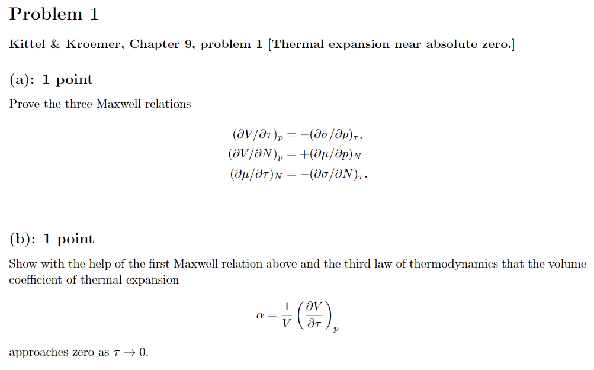

(a) We will apply cross-differentiation to get these results.

From the textbook:

$$ \frac{\partial G}{\partial N}_{\tau,p} = \mu \\ \frac{\partial G}{\partial \tau}_{N,p} = - \sigma \\ \frac{\partial G}{\partial p}_{N,\tau} = V \\ $$

We find that

$$ \begin{matrix} \frac{\partial \mu}{\partial p} = \frac{\partial^2 G}{\partial p \partial N} & \frac{\partial \mu}{\partial \tau} = \frac{\partial^2 G}{\partial \tau \partial N} \\ \frac{\partial \sigma}{\partial p} = -\frac{\partial^2 G}{\partial p \partial \tau} & \frac{\partial \sigma}{\partial N} = -\frac{\partial^2 G}{\partial \tau \partial N} \\ \frac{\partial V}{\partial N} = \frac{\partial^2 G}{\partial p \partial N} & \frac{\partial V}{\partial \tau} = \frac{\partial^2 G}{\partial p \partial \tau} \end{matrix} $$

Combining RHS like terms yields the maxwell relations.

(b) We want to show $\underset{\tau \rightarrow 0}{\lim} \alpha = 0$, but we currently have $\alpha(V)$.

$$ \frac{1}{V} = \frac{\partial p}{\partial G}_{N,\tau} \\ \alpha = \frac{\partial p}{\partial G}_{N,\tau} \frac{\partial V}{\partial \tau}_p \\ = - \frac{\partial p}{\partial G}_{N,\tau}\frac{\partial \sigma}{\partial p}_\tau \\ = - \frac{\partial \sigma}{\partial G}_{N,\tau} = \dots $$

Not too sure where to go from here, I was hoping we'd get a temperature dependence out. Since we know $\partial V/\partial \tau = -\partial\sigma/\partial p$ and at absolute zero entropy is independent of pressure, this must be zero.

**Q2**

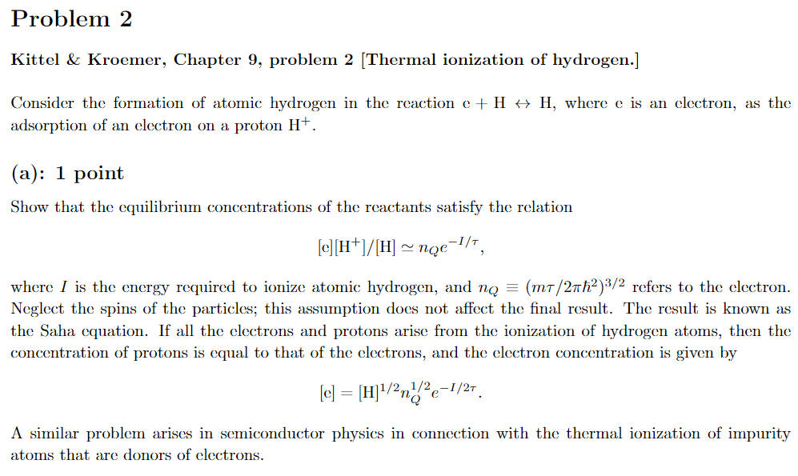

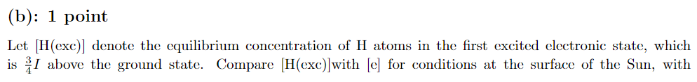

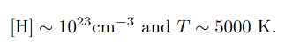

(a) The equilibrium is

$$ K(\tau) = \prod_j n_{Qj}^{vj} e^{-v_j F_j(\text{int})/\tau} = \frac{n_Q(e) n_Q (p)}{n_Q (H)} e^{F(H)/\tau} $$

Because electron mass is near zero, $n_Q(H)=n_Q(p)$ and they cancel out. This gives

$$ F(H) = - I \\ K(\tau) = n_Q(e) e^{-I/\tau} $$

(b) Use equation 3.9 from the textbook

$$ \frac{H(exe)}{H(ground)} = \frac{P(exe)}{P(ground)} = 4e^{-3I/4\tau} \\ H(exe) = 4 [H] \times e^{-23.68} = 2.07\times 10^{13} $$

**Q3**

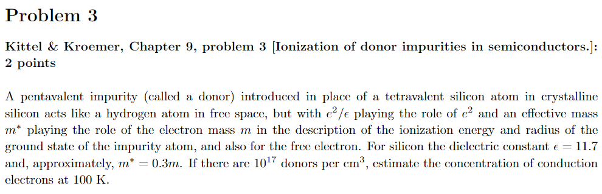

Using 9.47 from the book

$$ \frac{[e] [n_{donor}^+] }{[n_{donor}^0]} = n_Q (m^*) e^{-I^*/\tau} \equiv K $$

**Q4**

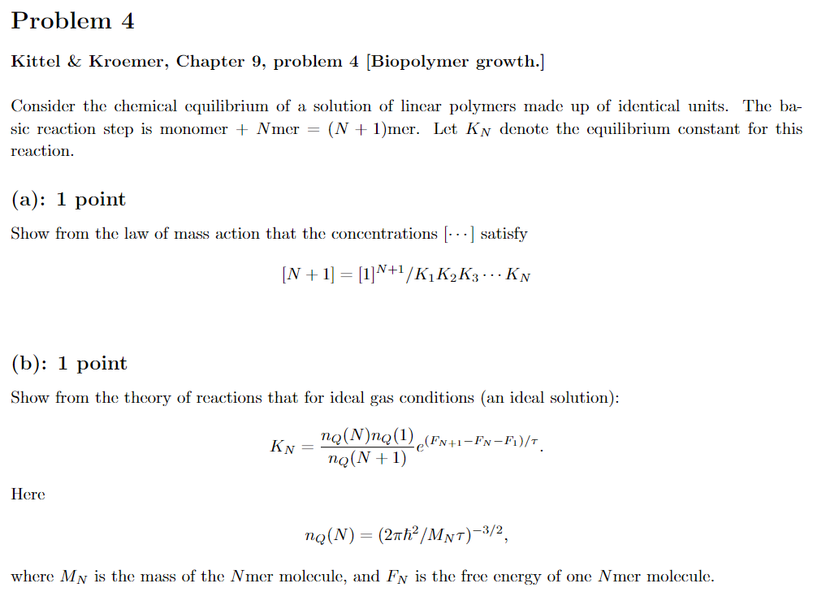

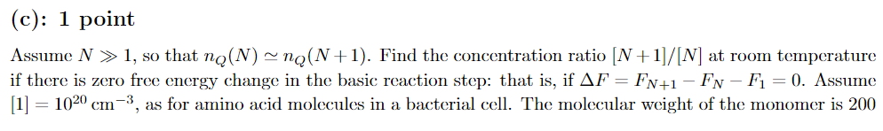

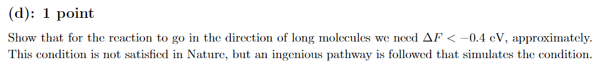

(a) Let's work through this $$ \\ \frac{[1][1]}{[2]} = K_1 \\ \frac{[1][2]}{[3]} = K_2 \\ \vdots \\ \frac{[1][N]}{[N+1]} = K_N $$

The product of all of these is

$$ \prod_i K_i = \frac{[1][1]^{N}}{[N+1]} = \frac{[1]^{N+1}}{[N+1]} \\ [N+1] = \frac{[1]^{N+1}}{\prod_i K_i} $$

(b) using $v(1) = v(N) = 1$ and $v(N+1) = -1$

$$ K_N(\tau) = \prod_j n_{Qj}^{vj} e^{-v_j F_j(\text{int})/\tau} = \frac{n_Q(N) n_Q(1)}{n_Q(N+1)}e^{F_{N+1}/\tau}e^{-F_N/\tau}e^{-F_1/\tau} \\ = \frac{n_Q(N) n_Q(1)}{n_Q(N+1)}e^{\frac{F_{N+1}-F_N-F_1}{\tau}} $$

(c)

(d) Need $[N+1]> [N]$, thus $K_N \leq [1]$

$$ K_N \leq 1 \Rightarrow \Delta F \leq -\tau \ln\left(\frac{n_Q(1)}{[1]}\right) $$

**Q5**

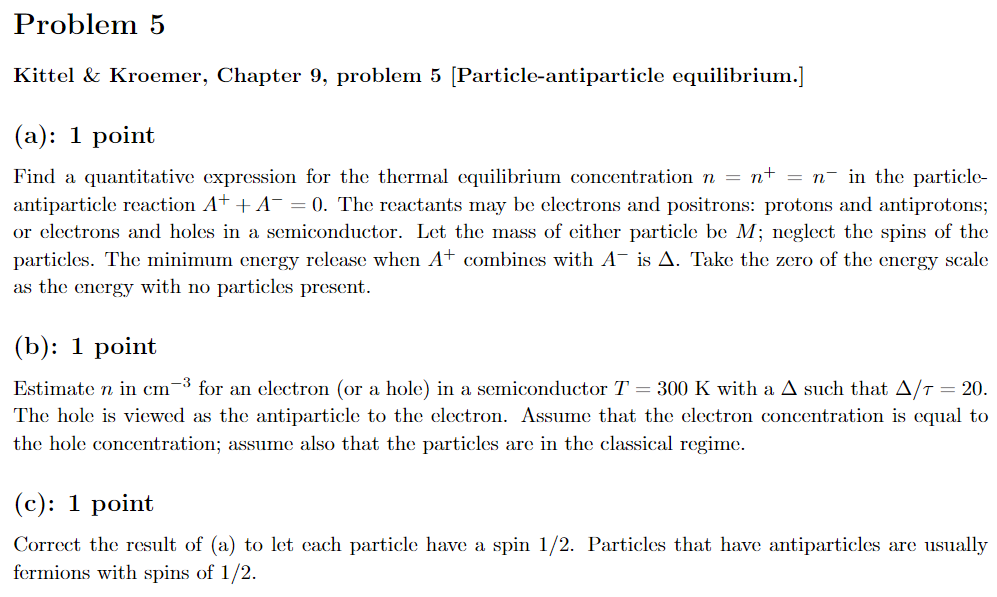

(a) Using (35) and putting it into (34)

$$ \prod_i n_i^{v_i} = \prod_i n_{Qi}^{vi} e^{-v_i F_i/\tau} \\ [A^+][A^-] = n_+ n_- = n_Q^2 e^{-\Delta/ \tau} \\ n = n_Q e^{\frac{-\Delta}{2\tau}} \\ $$

The hardest part was figuring out what equations to use

(b)

$$ 1.25\times 10^{19} e^{-10} = 5.7 \times 10^{14} \\ $$

(c) Two particles per state, so double the concentration

$$ n = 2n_Q e^{\frac{-\Delta}{2\tau}} \\ $$